# Understanding Factors Affecting States’ Maternal Mortality Ratio

Niharika Suri & Sookthi Kav

2023-11-25

#### Introduction

This is a course project for DT308: Quantitative Data Analysis for Public Policy, with Prof. V Sridhar and Prof. Amit Prakash. Niharika and I have used the following publicly available data sets to analyse possible factors that affect Indian states’ maternal morality rates:

- National Family Health Survey - 4 - 2014-15
- National Family Health Survey - 5 - 2019-20
- Sample Registration System (SRS) Special Bulletin on Maternal Mortality - 2014-15
- Sample Registration System (SRS) Special Bulletin on Maternal Mortality - 2018-20

#### Load libraries and read data

```r
library(car)
library(readxl)
library(ggplot2)
library(GGally)
library(readxl)
library(car)
library(stats)
library(corrplot)
library(dplyr)
nfhs <- read_excel("FINAL.xlsx")
my_data <- read_excel("FINAL.xlsx")
```

#### Specify variables

**Dependent variable:** Maternal Mortality Rate out of 1000 of each Indian state

- households_water: Households with an improved drinking-water source (%)
- maternity_antenatal_four: Mothers who had at least 4 antenatal care visits (%)
- maternity_csec: Births delivered by caesarean section (%)
- maternity_registration: Registered pregnancies for which the mother received Mother and Child Protection (MCP) card (%)

The following section shows all the variables available under `vif_variables`. The `#` are used before each variable to remove it from analysis.

```r
vif_variables <- c(
  'households_water',
  #'households_sanitation',
  #'households_iodized',
  #'households_healthinsurance',
  #'women_literate',
  #'men_literate',
  #'women_below19_mothers',
  #'infant_mortality',
  #'familyplanning_modern',
  #'maternity_antenatal_firsttrim',
  'maternity_antenatal_four',
  #'maternity_ironfolic',
  'maternity_registration',
  #'maternity_postnatal',
  #'maternity_hospital',
  'maternity_csec'
  #'women_lowbmi',
  #'women_nonpreg_anaemic',
  #'women_pregnant_anaemic'
  #'women_sugar_high'
  #'women_bp_high'
  #'women_decisions'
  #'women_ever_spousalviolence'
  #'women_pregnant_violence'
  #'women_bank'
  #'women_mobile'
)
```

#### Tidy

This section cleans the variables selected from the data sets and omits sections with missing values.

```r
# Convert selected variables to numeric
my_data[, c('MMR', vif_variables)] <- lapply(my_data[, c('MMR', vif_variables)], as.numeric)

# Handle missing values
my_data <- na.omit(my_data[, c('MMR', vif_variables)])
```

#### ANOVA

An analysis of variance was conducted to check for variance across states. The Pr (>F) value at 0.007, less than 0.05, indicates that there is significant state-wise difference in MMR.

Highest and Lowest MMR Values, NFHS-4 and NFHS-5

| Dataset | Highest MMR | State | Lowest MMR | State |
| --- | --- | --- | --- | --- |
| NFHS-4 | 237 | Assam | 46 | Kerala |
| NFHS-5 | 196 | Assam | 19 | Kerala |

```r
statesmmr_aov <- aov(MMR~states, data = nfhs)
summary(statesmmr_aov)
```

```
##             Df Sum Sq Mean Sq F value  Pr(>F)
## states      19  89655    4719   3.436 0.00797 **
## Residuals   16  21970    1373
## ---
## Signif. codes:  0 '***' 0.001 '**' 0.01 '*' 0.05 '.' 0.1 ' ' 1
## 36 observations deleted due to missingness
```

#### Linear Model & VIF

We used a multiple linear regression model on our variables.

```r
# Construct the formula for the linear model
formula_str <- paste("MMR ~", paste(vif_variables, collapse = " + "))
formula <- as.formula(formula_str)

#Linear model
lm_model <- lm(formula, data = my_data)


# Fit a linear model to calculate VIF
lm_model <- lm(formula, data = my_data)
summary(lm_model)
```

```
##
## Call:
## lm(formula = formula, data = my_data)
##
## Residuals:
##     Min      1Q  Median      3Q     Max
## -65.011 -26.230   5.021  22.289  73.086
##
## Coefficients:
##                          Estimate Std. Error t value Pr(>|t|)
## (Intercept)              169.5312   105.5779   1.606 0.118470
## households_water          -1.8273     0.9232  -1.979 0.056721 .
## maternity_antenatal_four  -1.6497     0.4540  -3.634 0.000999 ***
## maternity_registration     2.6542     1.0886   2.438 0.020688 *
## maternity_csec            -1.4275     0.6126  -2.330 0.026464 *
## ---
## Signif. codes:  0 '***' 0.001 '**' 0.01 '*' 0.05 '.' 0.1 ' ' 1
##
## Residual standard error: 35.69 on 31 degrees of freedom
## Multiple R-squared:  0.6462, Adjusted R-squared:  0.6005
## F-statistic: 14.15 on 4 and 31 DF,  p-value: 1.118e-06
```

#### Find Variance Inflation Factor

```r
# Calculate VIF
vif_values <- car::vif(lm_model)

# Display the VIF results
vif_data <- data.frame(Variable = names(vif_values), VIF = vif_values)
print(vif_data)
```

```
##                                          Variable      VIF
## households_water                 households_water 1.153249
## maternity_antenatal_four maternity_antenatal_four 2.092310
## maternity_registration     maternity_registration 1.241559
## maternity_csec                     maternity_csec 1.962559
```

None of the variables have a Variance Inflation Factor > 5. Hence, no significant multicollinearity.

#### Model Diagnostics: Heteroscedasticity

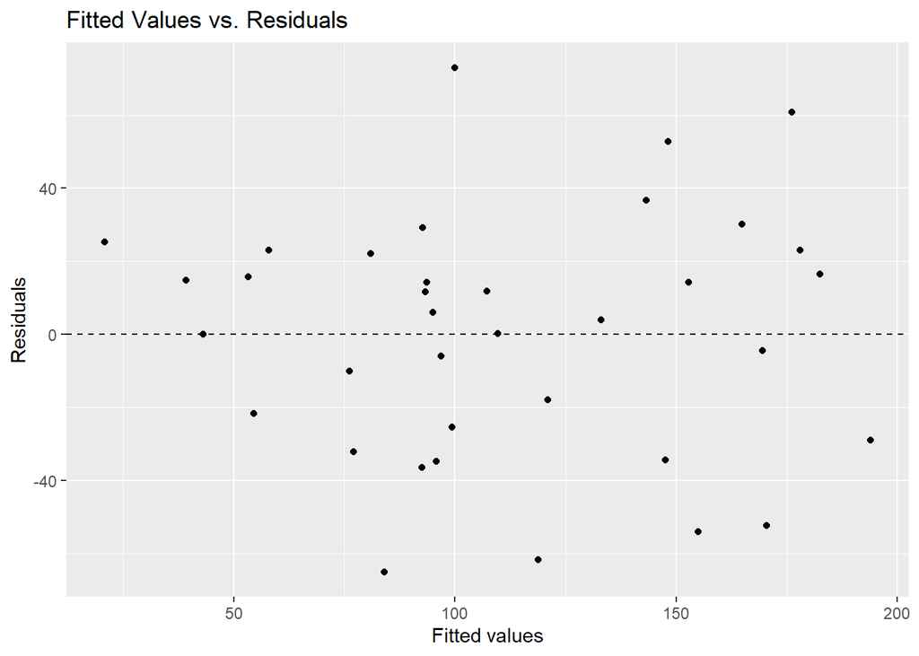

```r
ggplot(data = lm_model, aes(x = .fitted, y = .resid)) +
  geom_point() +
  geom_hline(yintercept = 0, linetype = "dashed") +
  labs(title = "Fitted Values vs. Residuals")+
  xlab("Fitted values") +
  ylab("Residuals")
```

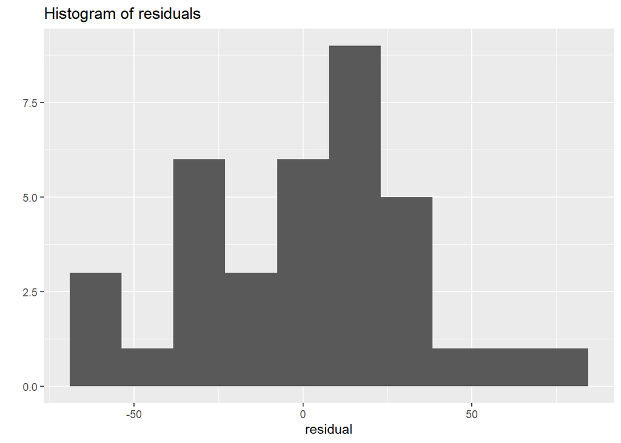

```r
qplot(lm_model$residuals,
               geom = "histogram",
               bins = 10) +
         labs(title = "Histogram of residuals",
              x = "residual")
```

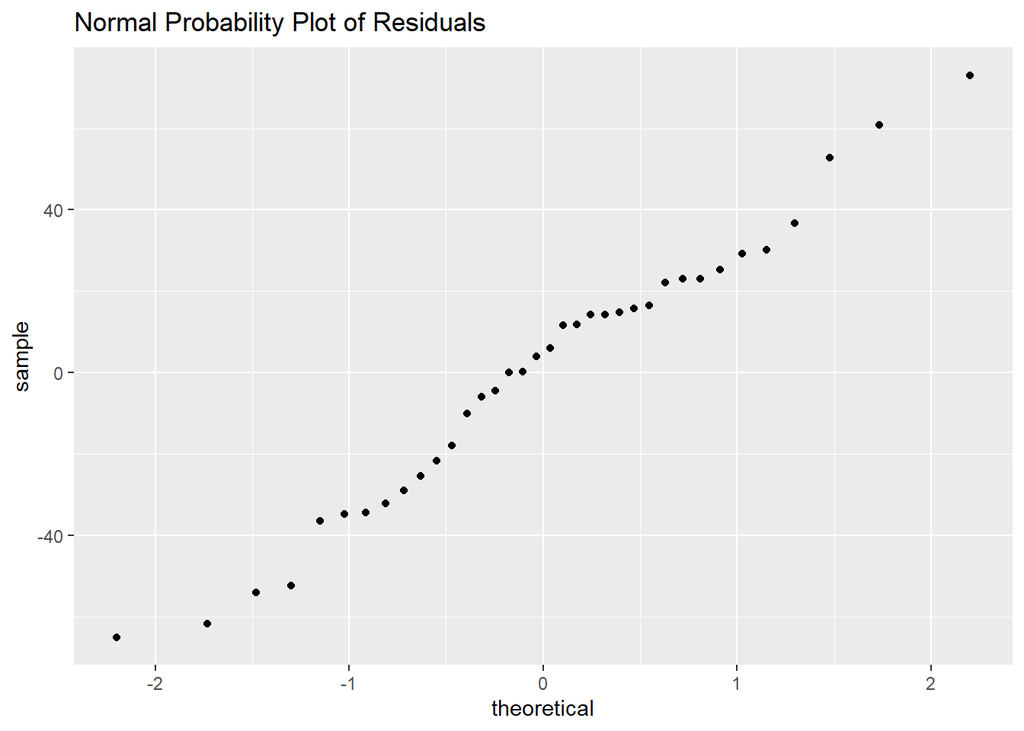

```r
ggplot(data = lm_model, aes(sample = .resid)) +
  stat_qq()+
  labs(title = "Normal Probability Plot of Residuals")
```

#### Policy Implications

- Access to at least four antenatal care visits is crucial to reducing maternal mortality rates in Indian, as our model shows.
- Increasing reach of the MCP programme across states may help in keeping track of maternal mortality. More research can assist in verifying this.
- States having higher c-section rates show lower MMR. This aligns to literature on developing countries that indicate that increased c-section rates improve birth outcomes (Ye et al, 2016).
  - Possible inference: Better hospital facilities in unreached or remote areas may allow for emergency c-section deliveries during complications. However, it is difficult to say that increasing c-section rates will reduce MMR, in general, and it is likely to be tied to various other social and geographic factors as well.
- Improving water and sanitation facilities and increasing access to clean, drinking water is important, to avoid pregnancy related complications (Cheng et al., 2012), which shows up in our findings as well.

#### References

- Cheng, J. J., Schuster-Wallace, C. J., Watt, S., Newbold, B. K., & Mente, A. (2012). An ecological quantification of the relationships between water, sanitation and infant, child, and maternal mortality. Environmental Health, 11(1), 4. https://doi.org/10.1186/1476-069X-11-4
- Velleman, Y., Mason, E., Graham, W., Benova, L., Chopra, M., Campbell, O. M. R., Gordon, B., Wijesekera, S., Hounton, S., Esteves Mills, J., Curtis, V., Afsana, K., Boisson, S., Magoma, M., Cairncross, S., & Cumming, O. (2014). From Joint Thinking to Joint Action: A Call to Action on Improving Water, Sanitation, and Hygiene for Maternal and Newborn Health. PLoS Medicine, 11(12), e1001771. https://doi.org/10.1371/journal.pmed.1001771
- Ye, J., Zhang, J., Mikolajczyk, R., Torloni, M., Gülmezoglu, A., & Betran, A. (2016). Association between rates of caesarean section and maternal and neonatal mortality in the 21st century: A worldwide population‐based ecological study with longitudinal data. BJOG: An International Journal of Obstetrics & Gynaecology, 123(5), 745–753. https://doi.org/10.1111/1471-0528.13592